# Financial Transaction Fraud Detection EDA

This notebook explores the PaySim financial transaction dataset for the V1 fraud detection project.

The goal of this notebook is to understand the data before building machine learning models. We will inspect the dataset structure, missing values, duplicate rows, class imbalance, transaction types, fraud patterns, and balance-related variables.

**Important:** This notebook does not train any model. Model training will be handled in the next notebook, `02_financial_ml_baseline.ipynb`.

## 1. Import Libraries

We use only `pandas` for data analysis and `matplotlib` for visualization in this notebook.

```python
from pathlib import Path

import pandas as pd
import matplotlib.pyplot as plt

pd.set_option("display.max_columns", None)
pd.set_option("display.float_format", "{:.4f}".format)

plt.style.use("default")
```

## 2. Load Dataset

The PaySim dataset should be placed manually at `data/raw/financial/paysim.csv`.

Because PaySim can be large, the code below first tries to load the full dataset. If a memory error occurs, it loads a smaller sample and clearly marks that the notebook is using sampled data.

```python
DATA_PATH = Path("../data/raw/financial/paysim.csv")

if not DATA_PATH.exists():
    DATA_PATH = Path(r"D:\cs s1 26\基于深度学习的交易欺诈检测与智能风控系统\transaction-fraud-detection-system\data\raw\financial\paysim.csv")

print(f"Dataset path: {DATA_PATH}")
print(f"Dataset exists: {DATA_PATH.exists()}")
```

```
Dataset path: D:\cs s1 26\基于深度学习的交易欺诈检测与智能风控系统\transaction-fraud-detection-system\data\raw\financial\paysim.csv
Dataset exists: True
```

```python
use_sample = False
sample_size = 200_000

try:
    df = pd.read_csv(DATA_PATH)
    print("Loaded full dataset.")
except MemoryError:
    use_sample = True
    df = pd.read_csv(DATA_PATH, nrows=sample_size)
    print(f"Memory issue detected. Loaded a sample of {sample_size:,} rows instead.")

print(f"Using sample: {use_sample}")
```

```
Loaded full dataset.
Using sample: False
```

**Observation:** If `Using sample` is `False`, the full dataset was loaded. If it is `True`, the results in this notebook should be treated as approximate because only part of the dataset was analyzed.

## 3. Dataset Shape and First Rows

We start by checking how many rows and columns are available, then preview the first few records.

```python
print(f"Rows: {df.shape[0]:,}")
print(f"Columns: {df.shape[1]:,}")

df.head()
```

```
Rows: 6,362,620
Columns: 11
```

|  | step | type | amount | nameOrig | oldbalanceOrg | newbalanceOrig | nameDest | oldbalanceDest | newbalanceDest | isFraud | isFlaggedFraud |
| --- | --- | --- | --- | --- | --- | --- | --- | --- | --- | --- | --- |
| 0 | 1 | PAYMENT | 9839.6400 | C1231006815 | 170136.0000 | 160296.3600 | M1979787155 | 0.0000 | 0.0000 | 0 | 0 |
| 1 | 1 | PAYMENT | 1864.2800 | C1666544295 | 21249.0000 | 19384.7200 | M2044282225 | 0.0000 | 0.0000 | 0 | 0 |
| 2 | 1 | TRANSFER | 181.0000 | C1305486145 | 181.0000 | 0.0000 | C553264065 | 0.0000 | 0.0000 | 1 | 0 |
| 3 | 1 | CASH_OUT | 181.0000 | C840083671 | 181.0000 | 0.0000 | C38997010 | 21182.0000 | 0.0000 | 1 | 0 |
| 4 | 1 | PAYMENT | 11668.1400 | C2048537720 | 41554.0000 | 29885.8600 | M1230701703 | 0.0000 | 0.0000 | 0 | 0 |

**Observation:** The first rows help us confirm that the dataset loaded correctly and show the main transaction fields, such as transaction type, amount, account balances, and the fraud label.

## 4. Column Names and Data Types

Data types are important because machine learning models require numeric input. Categorical fields such as transaction type will need encoding later.

```python
df.info()
```

```
<class 'pandas.core.frame.DataFrame'>
RangeIndex: 6362620 entries, 0 to 6362619
Data columns (total 11 columns):
 #   Column          Dtype
---  ------          -----
 0   step            int64
 1   type            object
 2   amount          float64
 3   nameOrig        object
 4   oldbalanceOrg   float64
 5   newbalanceOrig  float64
 6   nameDest        object
 7   oldbalanceDest  float64
 8   newbalanceDest  float64
 9   isFraud         int64
 10  isFlaggedFraud  int64
dtypes: float64(5), int64(3), object(3)
memory usage: 534.0+ MB
```

```python
df.dtypes
```

```
step                int64
type               object
amount            float64
nameOrig           object
oldbalanceOrg     float64
newbalanceOrig    float64
nameDest           object
oldbalanceDest    float64
newbalanceDest    float64
isFraud             int64
isFlaggedFraud      int64
dtype: object
```

**Observation:** The `type` column is categorical and will need to be converted into numerical features during feature engineering. Balance and amount columns are already numeric.

## 5. Missing Value Check

Missing values can affect both analysis and modeling. We check the number and percentage of missing values in each column.

```python
missing_summary = pd.DataFrame({
    "missing_count": df.isna().sum(),
    "missing_percent": df.isna().mean() * 100
})

missing_summary.sort_values("missing_count", ascending=False)
```

|  | missing_count | missing_percent |
| --- | --- | --- |
| step | 0 | 0.0000 |
| type | 0 | 0.0000 |
| amount | 0 | 0.0000 |
| nameOrig | 0 | 0.0000 |
| oldbalanceOrg | 0 | 0.0000 |
| newbalanceOrig | 0 | 0.0000 |
| nameDest | 0 | 0.0000 |
| oldbalanceDest | 0 | 0.0000 |
| newbalanceDest | 0 | 0.0000 |
| isFraud | 0 | 0.0000 |
| isFlaggedFraud | 0 | 0.0000 |

**Observation:** If missing values exist, they must be handled in `src/preprocessing.py`. If there are no missing values, preprocessing can focus more on feature engineering, scaling, and class imbalance.

## 6. Duplicate Row Check

Duplicate rows may indicate repeated records. We count duplicates before deciding whether any cleaning is required.

```python
duplicate_count = df.duplicated().sum()
duplicate_percent = duplicate_count / len(df) * 100

print(f"Duplicate rows: {duplicate_count:,}")
print(f"Duplicate percentage: {duplicate_percent:.4f}%")
```

```
Duplicate rows: 0
Duplicate percentage: 0.0000%
```

**Observation:** Duplicate records should be reviewed carefully. If duplicates are true repeated transactions, they may need to be removed. If they represent valid repeated behavior, they may need to stay.

## 7. Fraud Class Distribution

The target column is `isFraud`. Fraud detection datasets are usually highly imbalanced, meaning fraudulent transactions are much rarer than normal transactions.

```python
fraud_counts = df["isFraud"].value_counts().sort_index()
fraud_percent = df["isFraud"].value_counts(normalize=True).sort_index() * 100

fraud_distribution = pd.DataFrame({
    "count": fraud_counts,
    "percent": fraud_percent
})

fraud_distribution
```

| isFraud | count | percent |
| --- | --- | --- |
| 0 | 6354407 | 99.8709 |
| 1 | 8213 | 0.1291 |

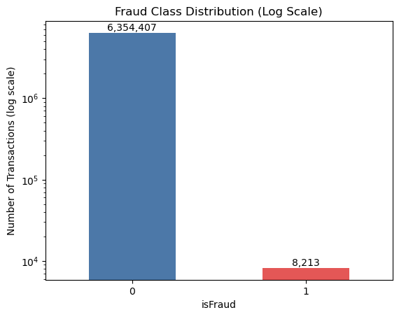

```python
ax = fraud_counts.plot(kind="bar", color=["#4C78A8", "#E45756"], logy=True)
plt.title("Fraud Class Distribution (Log Scale)")
plt.xlabel("isFraud")
plt.ylabel("Number of Transactions (log scale)")
plt.xticks(rotation=0)

for index, value in enumerate(fraud_counts):
    ax.text(index, value, f"{value:,}", ha="center", va="bottom")

plt.show()
```

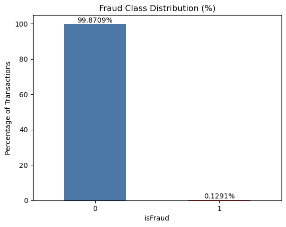

```python
ax = fraud_percent.plot(kind="bar", color=["#4C78A8", "#E45756"])
plt.title("Fraud Class Distribution (%)")
plt.xlabel("isFraud")
plt.ylabel("Percentage of Transactions")
plt.xticks(rotation=0)

for index, value in enumerate(fraud_percent):
    ax.text(index, value, f"{value:.4f}%", ha="center", va="bottom")

plt.show()
```

**Observation:** This project is expected to have strong class imbalance. A normal bar chart can make the fraud class almost invisible, so the log-scale chart makes the minority class easier to see while still showing the large gap between normal and fraud transactions. The percentage chart makes the imbalance even clearer. Accuracy alone is not enough because a model could predict most transactions as normal and still achieve high accuracy while missing fraud cases. Metrics such as recall, precision, F1 score, ROC-AUC, and PR-AUC will be more useful.

## 8. Transaction Type Distribution

The `type` column describes the transaction category. We inspect how often each transaction type appears.

```python
type_counts = df["type"].value_counts()
type_percent = df["type"].value_counts(normalize=True) * 100

type_distribution = pd.DataFrame({
    "count": type_counts,
    "percent": type_percent
})

type_distribution
```

| type | count | percent |
| --- | --- | --- |
| CASH_OUT | 2237500 | 35.1663 |
| PAYMENT | 2151495 | 33.8146 |
| CASH_IN | 1399284 | 21.9923 |
| TRANSFER | 532909 | 8.3756 |
| DEBIT | 41432 | 0.6512 |

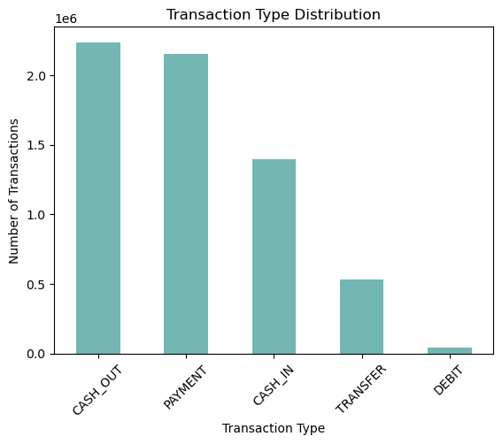

```python
type_counts.plot(kind="bar", color="#72B7B2")
plt.title("Transaction Type Distribution")
plt.xlabel("Transaction Type")
plt.ylabel("Number of Transactions")
plt.xticks(rotation=45)
plt.show()
```

**Observation:** Transaction type is likely an important feature. If some types occur much more often than others, models may learn different fraud patterns for each type.

## 9. Fraud Rate by Transaction Type

Fraud rate shows the percentage of transactions that are fraudulent within each transaction type.

```python
fraud_rate_by_type = df.groupby("type")["isFraud"].agg(["count", "sum", "mean"])
fraud_rate_by_type = fraud_rate_by_type.rename(columns={
    "count": "total_transactions",
    "sum": "fraud_transactions",
    "mean": "fraud_rate"
})
fraud_rate_by_type["fraud_rate_percent"] = fraud_rate_by_type["fraud_rate"] * 100

fraud_rate_by_type.sort_values("fraud_rate_percent", ascending=False)
```

| type | total_transactions | fraud_transactions | fraud_rate | fraud_rate_percent |
| --- | --- | --- | --- | --- |
| TRANSFER | 532909 | 4097 | 0.0077 | 0.7688 |
| CASH_OUT | 2237500 | 4116 | 0.0018 | 0.1840 |
| CASH_IN | 1399284 | 0 | 0.0000 | 0.0000 |
| DEBIT | 41432 | 0 | 0.0000 | 0.0000 |
| PAYMENT | 2151495 | 0 | 0.0000 | 0.0000 |

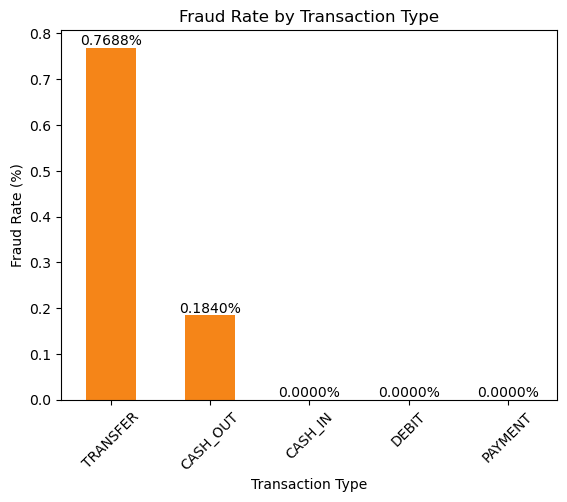

```python
fraud_rate_plot = fraud_rate_by_type["fraud_rate_percent"].sort_values(ascending=False)

ax = fraud_rate_plot.plot(kind="bar", color="#F58518")
plt.title("Fraud Rate by Transaction Type")
plt.xlabel("Transaction Type")
plt.ylabel("Fraud Rate (%)")
plt.xticks(rotation=45)

for index, value in enumerate(fraud_rate_plot):
    ax.text(index, value, f"{value:.4f}%", ha="center", va="bottom")

plt.show()
```

**Observation:** Fraud rate is useful for imbalanced data because total transaction counts can hide risk. A transaction type may have many transactions but a low fraud rate, while another type may have fewer transactions but a much higher share of fraud. In PaySim, fraud is commonly associated with `TRANSFER` and `CASH_OUT` transactions.

## 10. Amount Distribution for Normal vs Fraud Transactions

Transaction amount is often one of the most important fraud detection features. Because amounts can have extreme values, we inspect summary statistics and plot a capped histogram for readability.

```python
df.groupby("isFraud")["amount"].describe()
```

| isFraud | count | mean | std | min | 25% | 50% | 75% | max |
| --- | --- | --- | --- | --- | --- | --- | --- | --- |
| 0 | 6354407.0000 | 178197.0417 | 596236.9813 | 0.0100 | 13368.3950 | 74684.7200 | 208364.7600 | 92445516.6400 |
| 1 | 8213.0000 | 1467967.2991 | 2404252.9472 | 0.0000 | 127091.3300 | 441423.4400 | 1517771.4800 | 10000000.0000 |

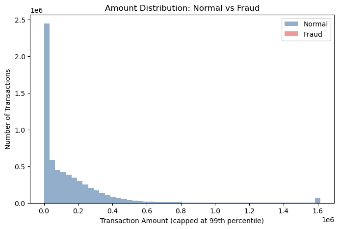

```
Amount cap used for visualization: 1,615,979.47
```

```python
amount_cap = df["amount"].quantile(0.99)
normal_amount = df.loc[df["isFraud"] == 0, "amount"].clip(upper=amount_cap)
fraud_amount = df.loc[df["isFraud"] == 1, "amount"].clip(upper=amount_cap)

plt.figure(figsize=(8, 5))
plt.hist(normal_amount, bins=50, alpha=0.6, label="Normal", color="#4C78A8")
plt.hist(fraud_amount, bins=50, alpha=0.6, label="Fraud", color="#E45756")
plt.title("Amount Distribution: Normal vs Fraud")
plt.xlabel("Transaction Amount (capped at 99th percentile)")
plt.ylabel("Number of Transactions")
plt.legend()
plt.show()

print(f"Amount cap used for visualization: {amount_cap:,.2f}")
```

**Observation:** Comparing normal and fraudulent transaction amounts helps identify whether fraud tends to happen at larger values, smaller values, or across a wide range. Capping is used only for visualization so that extreme values do not dominate the chart.

## 11. Balance-Related Analysis

PaySim includes origin and destination account balances before and after each transaction. These columns can help detect unusual balance changes.

```python
balance_columns = ["oldbalanceOrg", "newbalanceOrig", "oldbalanceDest", "newbalanceDest"]

df.groupby("isFraud")[balance_columns].describe().T
```

|  | isFraud | 0 | 1 |
| --- | --- | --- | --- |
| oldbalanceOrg | count | 6354407.0000 | 8213.0000 |
|  | mean | 832828.7117 | 1649667.6057 |
|  | std | 2887144.0304 | 3547719.4391 |
|  | min | 0.0000 | 0.0000 |
|  | 25% | 0.0000 | 125822.4400 |
|  | 50% | 14069.0000 | 438983.4500 |
|  | 75% | 106969.5000 | 1517771.4800 |
|  | max | 43818855.3000 | 59585040.3700 |
| newbalanceOrig | count | 6354407.0000 | 8213.0000 |
|  | mean | 855970.2281 | 192392.6318 |
|  | std | 2924986.9647 | 1965666.4557 |
|  | min | 0.0000 | 0.0000 |
|  | 25% | 0.0000 | 0.0000 |
|  | 50% | 0.0000 | 0.0000 |
|  | 75% | 144730.7400 | 0.0000 |
|  | max | 43686616.3300 | 49585040.3700 |
| oldbalanceDest | count | 6354407.0000 | 8213.0000 |
|  | mean | 1101420.8746 | 544249.6191 |
|  | std | 3399201.7933 | 3336420.9509 |
|  | min | 0.0000 | 0.0000 |
|  | 25% | 0.0000 | 0.0000 |
|  | 50% | 133311.8000 | 0.0000 |
|  | 75% | 944144.5800 | 147828.6600 |
|  | max | 356015889.3500 | 236230516.8200 |
| newbalanceDest | count | 6354407.0000 | 8213.0000 |
|  | mean | 1224925.6846 | 1279707.6171 |
|  | std | 3673815.7100 | 3908816.5338 |
|  | min | 0.0000 | 0.0000 |
|  | 25% | 0.0000 | 0.0000 |
|  | 50% | 214881.7000 | 4676.4200 |
|  | 75% | 1111975.3450 | 1058725.2200 |
|  | max | 356179278.9200 | 236726494.6600 |

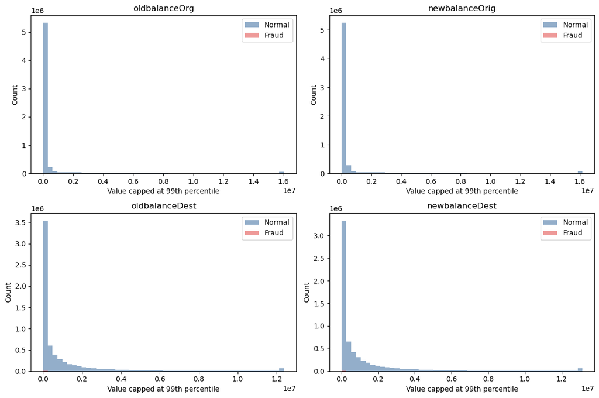

```python
fig, axes = plt.subplots(2, 2, figsize=(12, 8))
axes = axes.flatten()

for ax, column in zip(axes, balance_columns):
    cap = df[column].quantile(0.99)
    normal_values = df.loc[df["isFraud"] == 0, column].clip(upper=cap)
    fraud_values = df.loc[df["isFraud"] == 1, column].clip(upper=cap)

    ax.hist(normal_values, bins=50, alpha=0.6, label="Normal", color="#4C78A8")
    ax.hist(fraud_values, bins=50, alpha=0.6, label="Fraud", color="#E45756")
    ax.set_title(column)
    ax.set_xlabel("Value capped at 99th percentile")
    ax.set_ylabel("Count")
    ax.legend()

plt.tight_layout()
plt.show()
```

**Observation:** Balance fields may contain useful fraud signals. For feature engineering, we can create new variables such as origin balance change, destination balance change, and whether balances match the transaction amount.

## 12. Fraud Cases by Transaction Type

Next, we focus only on fraudulent transactions and inspect which transaction types appear most often.

```python
fraud_df = df[df["isFraud"] == 1]

fraud_type_counts = fraud_df["type"].value_counts()
fraud_type_percent = fraud_df["type"].value_counts(normalize=True) * 100

fraud_type_summary = pd.DataFrame({
    "fraud_count": fraud_type_counts,
    "fraud_percent": fraud_type_percent
})

fraud_type_summary
```

| type | fraud_count | fraud_percent |
| --- | --- | --- |
| CASH_OUT | 4116 | 50.1157 |
| TRANSFER | 4097 | 49.8843 |

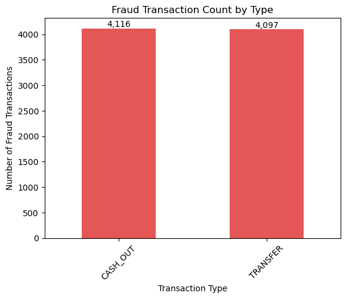

```python
ax = fraud_type_counts.plot(kind="bar", color="#E45756")
plt.title("Fraud Transaction Count by Type")
plt.xlabel("Transaction Type")
plt.ylabel("Number of Fraud Transactions")
plt.xticks(rotation=45)

for index, value in enumerate(fraud_type_counts):
    ax.text(index, value, f"{value:,}", ha="center", va="bottom")

plt.show()
```

```python
transfer_cashout = df[df["type"].isin(["TRANSFER", "CASH_OUT"])]

transfer_cashout_summary = transfer_cashout.groupby("type")["isFraud"].agg(["count", "sum", "mean"])
transfer_cashout_summary = transfer_cashout_summary.rename(columns={
    "count": "total_transactions",
    "sum": "fraud_transactions",
    "mean": "fraud_rate"
})
transfer_cashout_summary["fraud_rate_percent"] = transfer_cashout_summary["fraud_rate"] * 100

transfer_cashout_summary
```

| type | total_transactions | fraud_transactions | fraud_rate | fraud_rate_percent |
| --- | --- | --- | --- | --- |
| CASH_OUT | 2237500 | 4116 | 0.0018 | 0.1840 |
| TRANSFER | 532909 | 4097 | 0.0077 | 0.7688 |

**Observation:** Fraud cases in PaySim are especially important to inspect for `TRANSFER` and `CASH_OUT`. These transaction types should be handled carefully during feature engineering and model evaluation.

## 13. Simple EDA Observations

Based on the analysis above:

1. **Class imbalance:** Fraud transactions are much rarer than normal transactions. This means the model must be evaluated with fraud-focused metrics, not only accuracy.
2. **Important transaction types:** Fraud is expected to be most associated with `TRANSFER` and `CASH_OUT` transactions in PaySim. Transaction type should be an important feature.
3. **Accuracy is not enough:** If only a tiny percentage of transactions are fraud, a model can get high accuracy by predicting almost everything as normal. For fraud detection, missing fraud cases is costly, so recall, precision, F1 score, ROC-AUC, and PR-AUC are more meaningful.
4. **Balance features matter:** Origin and destination balance changes may reveal suspicious transaction behavior and should be used for feature engineering.

## 14. Feature Relationship Exploration for Feature Engineering

This section creates temporary engineered features inside the notebook. These features are not saved to disk yet. The goal is to understand whether they may be useful for the next ML baseline notebook and later implementation in `src/preprocessing.py`.

```python
eda_features = df.copy()

eda_features["orig_balance_change"] = eda_features["oldbalanceOrg"] - eda_features["newbalanceOrig"]
eda_features["dest_balance_change"] = eda_features["newbalanceDest"] - eda_features["oldbalanceDest"]
eda_features["orig_balance_error"] = eda_features["oldbalanceOrg"] - eda_features["newbalanceOrig"] - eda_features["amount"]
eda_features["dest_balance_error"] = eda_features["newbalanceDest"] - eda_features["oldbalanceDest"] - eda_features["amount"]
eda_features["amount_to_oldbalanceOrg_ratio"] = eda_features["amount"] / (eda_features["oldbalanceOrg"] + 1)
eda_features["is_orig_balance_drained"] = (eda_features["newbalanceOrig"] == 0).astype(int)
eda_features["is_high_risk_type"] = eda_features["type"].isin(["TRANSFER", "CASH_OUT"]).astype(int)

engineered_features = [
    "orig_balance_change",
    "dest_balance_change",
    "orig_balance_error",
    "dest_balance_error",
    "amount_to_oldbalanceOrg_ratio",
    "is_orig_balance_drained",
    "is_high_risk_type",
]

eda_features[engineered_features].head()
```

|  | orig_balance_change | dest_balance_change | orig_balance_error | dest_balance_error | amount_to_oldbalanceOrg_ratio | is_orig_balance_drained | is_high_risk_type |
| --- | --- | --- | --- | --- | --- | --- | --- |
| 0 | 9839.6400 | 0.0000 | 0.0000 | -9839.6400 | 0.0578 | 0 | 0 |
| 1 | 1864.2800 | 0.0000 | -0.0000 | -1864.2800 | 0.0877 | 0 | 0 |
| 2 | 181.0000 | 0.0000 | 0.0000 | -181.0000 | 0.9945 | 1 | 1 |
| 3 | 181.0000 | -21182.0000 | 0.0000 | -21363.0000 | 0.9945 | 1 | 1 |
| 4 | 11668.1400 | 0.0000 | 0.0000 | -11668.1400 | 0.2808 | 0 | 0 |

**Observation:** These features are based on transaction behavior rather than model output. They describe balance movement, possible balance inconsistencies, transaction amount relative to the sender balance, whether the sender account was drained, and whether the transaction belongs to a high-risk PaySim type.

### Compare Engineered Features Between Normal and Fraud Transactions

We compare the mean and median of each temporary engineered feature for normal and fraudulent transactions.

```python
feature_summary_by_fraud = eda_features.groupby("isFraud")[engineered_features].agg(["mean", "median"])
feature_summary_by_fraud.T
```

|  | isFraud | 0 | 1 |
| --- | --- | --- | --- |
| orig_balance_change | mean | -23141.5164 | 1457274.9739 |
|  | median | 0.0000 | 436317.4900 |
| dest_balance_change | mean | 123504.8100 | 735457.9981 |
|  | median | 0.0000 | 0.0000 |
| orig_balance_error | mean | -201338.5581 | -10692.3253 |
|  | median | -69049.3100 | 0.0000 |
| dest_balance_error | mean | -54692.2317 | -732509.3011 |
|  | median | -3500.6800 | -2231.4600 |
| amount_to_oldbalanceOrg_ratio | mean | 70764.3209 | 1161.9667 |
|  | median | 6.5116 | 1.0000 |
| is_orig_balance_drained | mean | 0.5668 | 0.9805 |
|  | median | 1.0000 | 1.0000 |
| is_high_risk_type | mean | 0.4347 | 1.0000 |
|  | median | 0.0000 | 1.0000 |

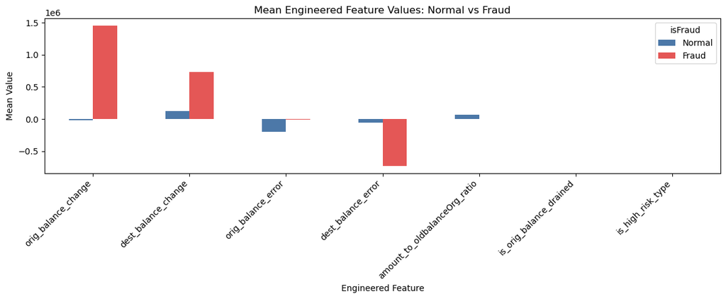

```python
mean_features_by_fraud = eda_features.groupby("isFraud")[engineered_features].mean().T

mean_features_by_fraud.plot(kind="bar", figsize=(12, 5), color=["#4C78A8", "#E45756"])
plt.title("Mean Engineered Feature Values: Normal vs Fraud")
plt.xlabel("Engineered Feature")
plt.ylabel("Mean Value")
plt.xticks(rotation=45, ha="right")
plt.legend(["Normal", "Fraud"], title="isFraud")
plt.tight_layout()
plt.show()
```

**Observation:** Features with noticeably different mean or median values between normal and fraud transactions are good candidates for `preprocessing.py`. In particular, balance changes, balance errors, high-risk transaction type, and account-drained indicators may help supervised models separate fraud from normal behavior.

### Engineered Features by Transaction Type and Fraud Label

Because PaySim fraud is strongly connected to `TRANSFER` and `CASH_OUT`, we compare selected engineered features within those transaction types.

```python
selected_features = [
    "amount",
    "orig_balance_change",
    "dest_balance_change",
    "orig_balance_error",
    "dest_balance_error",
    "amount_to_oldbalanceOrg_ratio",
    "is_orig_balance_drained",
]

high_risk_type_features = eda_features[eda_features["type"].isin(["TRANSFER", "CASH_OUT"])]

high_risk_type_summary = high_risk_type_features.groupby(["type", "isFraud"])[selected_features].median()
high_risk_type_summary
```

| type | isFraud | amount | orig_balance_change | dest_balance_change | orig_balance_error | dest_balance_error | amount_to_oldbalanceOrg_ratio | is_orig_balance_drained |
| --- | --- | --- | --- | --- | --- | --- | --- | --- |
| CASH_OUT | 0 | 146946.5600 | 524.0000 | 150052.4600 | -119824.2150 | 0.0000 | 253.2587 | 1.0000 |
|  | 1 | 435516.9050 | 433677.7450 | 439782.3000 | 0.0000 | 0.0000 | 1.0000 | 1.0000 |
| TRANSFER | 0 | 486521.9100 | 0.0000 | 498881.6700 | -454033.0800 | 0.0000 | 55288.7647 | 1.0000 |
|  | 1 | 445705.7600 | 438394.6700 | 0.0000 | 0.0000 | -442722.0100 | 1.0000 | 1.0000 |

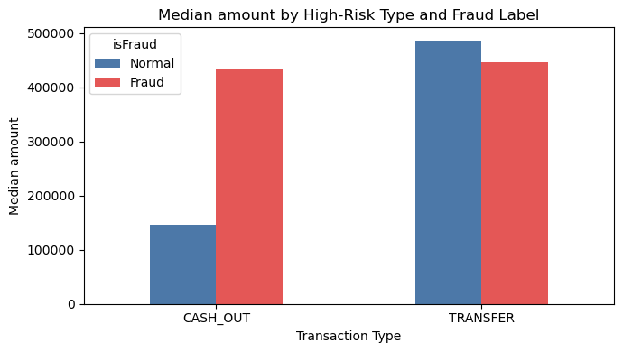

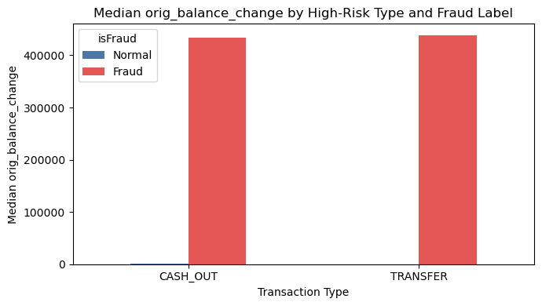

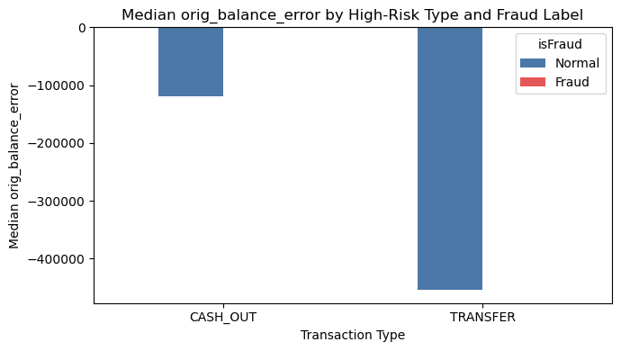

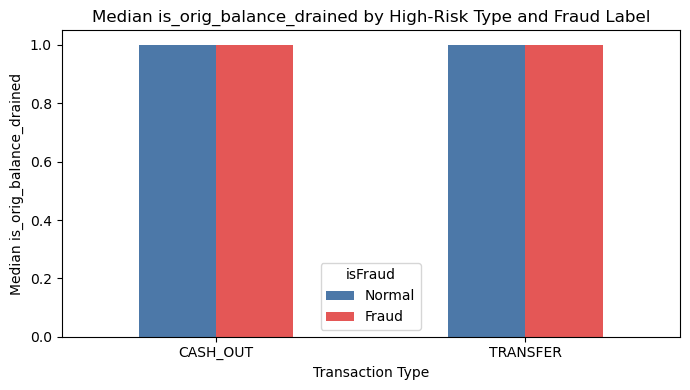

```python
plot_features = ["amount", "orig_balance_change", "orig_balance_error", "is_orig_balance_drained"]

for feature in plot_features:
    plot_data = high_risk_type_features.groupby(["type", "isFraud"])[feature].median().unstack()
    ax = plot_data.plot(kind="bar", figsize=(7, 4), color=["#4C78A8", "#E45756"])
    plt.title(f"Median {feature} by High-Risk Type and Fraud Label")
    plt.xlabel("Transaction Type")
    plt.ylabel(f"Median {feature}")
    plt.xticks(rotation=0)
    plt.legend(["Normal", "Fraud"], title="isFraud")
    plt.tight_layout()
    plt.show()
```

**Observation:** Comparing engineered features inside `TRANSFER` and `CASH_OUT` avoids mixing very different transaction behaviors. If fraud and normal transactions have different balance movement patterns within the same type, those engineered features are more likely to help the ML baseline models.

### Correlation Matrix for Numeric and Engineered Features

A correlation matrix gives a quick view of relationships between numeric variables, engineered features, and the fraud label. Correlation does not prove causation, but it can help identify useful or redundant features.

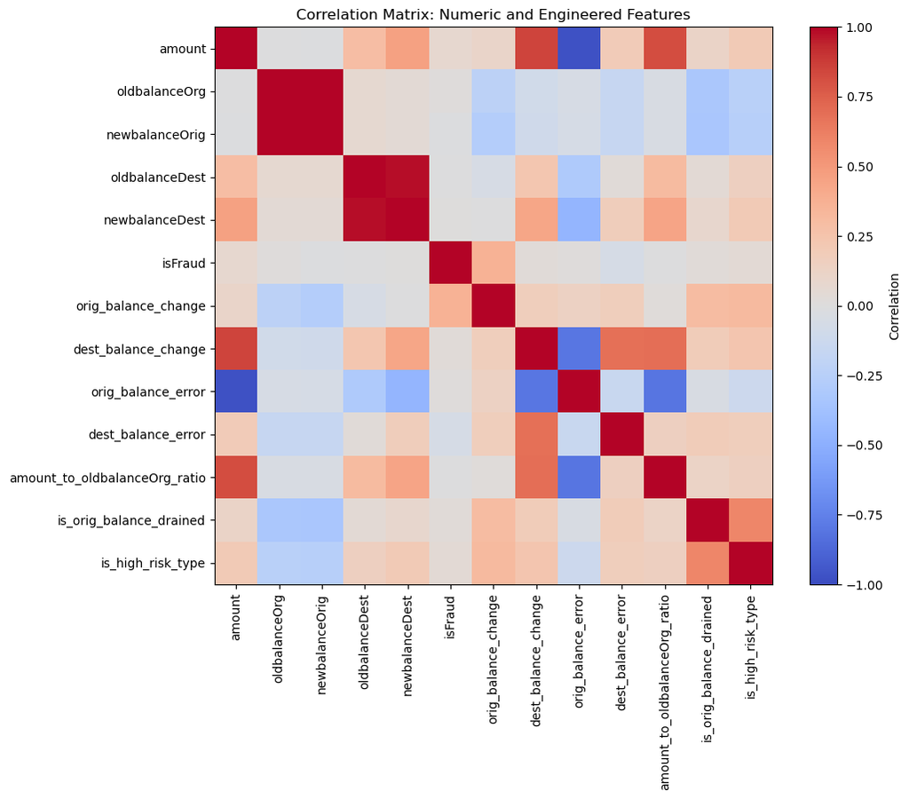

|  | amount | oldbalanceOrg | newbalanceOrig | oldbalanceDest | newbalanceDest | isFraud | orig_balance_change | dest_balance_change | orig_balance_error | dest_balance_error | amount_to_oldbalanceOrg_ratio | is_orig_balance_drained | is_high_risk_type |
| --- | --- | --- | --- | --- | --- | --- | --- | --- | --- | --- | --- | --- | --- |
| amount | 1.0000 | -0.0028 | -0.0079 | 0.2941 | 0.4593 | 0.0767 | 0.1023 | 0.8460 | -0.9707 | 0.1899 | 0.8171 | 0.1156 | 0.2002 |
| oldbalanceOrg | -0.0028 | 1.0000 | 0.9988 | 0.0662 | 0.0420 | 0.0102 | -0.2203 | -0.0870 | -0.0505 | -0.1565 | -0.0401 | -0.3237 | -0.2391 |
| newbalanceOrig | -0.0079 | 0.9988 | 1.0000 | 0.0678 | 0.0418 | -0.0081 | -0.2678 | -0.0945 | -0.0569 | -0.1632 | -0.0406 | -0.3349 | -0.2520 |
| oldbalanceDest | 0.2941 | 0.0662 | 0.0678 | 1.0000 | 0.9766 | -0.0059 | -0.0475 | 0.2323 | -0.3043 | 0.0255 | 0.3078 | 0.0414 | 0.1557 |
| newbalanceDest | 0.4593 | 0.0420 | 0.0418 | 0.9766 | 1.0000 | 0.0005 | -0.0065 | 0.4362 | -0.4587 | 0.1749 | 0.4375 | 0.0798 | 0.1971 |
| isFraud | 0.0767 | 0.0102 | -0.0081 | -0.0059 | 0.0005 | 1.0000 | 0.3625 | 0.0270 | 0.0113 | -0.0551 | -0.0049 | 0.0300 | 0.0409 |
| orig_balance_change | 0.1023 | -0.2203 | -0.2678 | -0.0475 | -0.0065 | 0.3625 | 1.0000 | 0.1693 | 0.1399 | 0.1717 | 0.0187 | 0.3011 | 0.3161 |
| dest_balance_change | 0.8460 | -0.0870 | -0.0945 | 0.2323 | 0.4362 | 0.0270 | 0.1693 | 1.0000 | -0.8011 | 0.6842 | 0.6902 | 0.1874 | 0.2397 |
| orig_balance_error | -0.9707 | -0.0505 | -0.0569 | -0.3043 | -0.4587 | 0.0113 | 0.1399 | -0.8011 | 1.0000 | -0.1475 | -0.8088 | -0.0423 | -0.1229 |
| dest_balance_error | 0.1899 | -0.1565 | -0.1632 | 0.0255 | 0.1749 | -0.0551 | 0.1717 | 0.6842 | -0.1475 | 1.0000 | 0.1533 | 0.1871 | 0.1675 |
| amount_to_oldbalanceOrg_ratio | 0.8171 | -0.0401 | -0.0406 | 0.3078 | 0.4375 | -0.0049 | 0.0187 | 0.6902 | -0.8088 | 0.1533 | 1.0000 | 0.1199 | 0.1503 |
| is_orig_balance_drained | 0.1156 | -0.3237 | -0.3349 | 0.0414 | 0.0798 | 0.0300 | 0.3011 | 0.1874 | -0.0423 | 0.1871 | 0.1199 | 1.0000 | 0.5918 |
| is_high_risk_type | 0.2002 | -0.2391 | -0.2520 | 0.1557 | 0.1971 | 0.0409 | 0.3161 | 0.2397 | -0.1229 | 0.1675 | 0.1503 | 0.5918 | 1.0000 |

```python
correlation_columns = [
    "amount",
    "oldbalanceOrg",
    "newbalanceOrig",
    "oldbalanceDest",
    "newbalanceDest",
    "isFraud",
] + engineered_features

corr_matrix = eda_features[correlation_columns].corr()

plt.figure(figsize=(11, 9))
plt.imshow(corr_matrix, cmap="coolwarm", vmin=-1, vmax=1)
plt.colorbar(label="Correlation")
plt.xticks(range(len(corr_matrix.columns)), corr_matrix.columns, rotation=90)
plt.yticks(range(len(corr_matrix.index)), corr_matrix.index)
plt.title("Correlation Matrix: Numeric and Engineered Features")
plt.tight_layout()
plt.show()

corr_matrix
```

**Observation:** Features with stronger relationships to `isFraud` are useful candidates for the ML baseline notebook. Features that are highly correlated with each other may carry overlapping information, so they should be monitored during model evaluation. For V1 preprocessing, the most useful candidates are likely `orig_balance_change`, `dest_balance_change`, `orig_balance_error`, `dest_balance_error`, `amount_to_oldbalanceOrg_ratio`, `is_orig_balance_drained`, and `is_high_risk_type` because they translate raw transaction fields into direct behavioral signals.

## 15. Fraud Rate Analysis for Representative Engineered Features

This section checks whether selected engineered features show fraud-related patterns. Instead of using these tables as model inputs, we use them to support the business logic behind feature engineering.

The five representative features are:

- `orig_balance_change`: fund outflow from the origin account.
- `orig_balance_error`: whether the origin balance change matches the transaction amount.
- `amount_to_oldbalanceOrg_ratio`: transaction size relative to the origin account's starting balance.
- `is_orig_balance_drained`: whether the origin account balance becomes zero after the transaction.
- `is_high_risk_type`: whether the transaction is `TRANSFER` or `CASH_OUT`.

### Binary Feature Fraud Rates

For binary features, we group transactions by feature value and calculate total transactions, fraud transactions, fraud rate, and fraud rate percentage.

```python
binary_features = ["is_orig_balance_drained", "is_high_risk_type"]

binary_fraud_rate_tables = {}

for feature in binary_features:
    fraud_rate_table = eda_features.groupby(feature).agg(
        total_count=("isFraud", "count"),
        fraud_count=("isFraud", "sum"),
        fraud_rate=("isFraud", "mean")
    )
    fraud_rate_table["fraud_rate_percent"] = fraud_rate_table["fraud_rate"] * 100
    binary_fraud_rate_tables[feature] = fraud_rate_table

binary_fraud_rate_tables["is_orig_balance_drained"]
```

| is_orig_balance_drained | total_count | fraud_count | fraud_rate | fraud_rate_percent |
| --- | --- | --- | --- | --- |
| 0 | 2753054 | 160 | 0.0001 | 0.0058 |
| 1 | 3609566 | 8053 | 0.0022 | 0.2231 |

```python
binary_fraud_rate_tables["is_high_risk_type"]
```

| is_high_risk_type | total_count | fraud_count | fraud_rate | fraud_rate_percent |
| --- | --- | --- | --- | --- |
| 0 | 3592211 | 0 | 0.0000 | 0.0000 |
| 1 | 2770409 | 8213 | 0.0030 | 0.2965 |

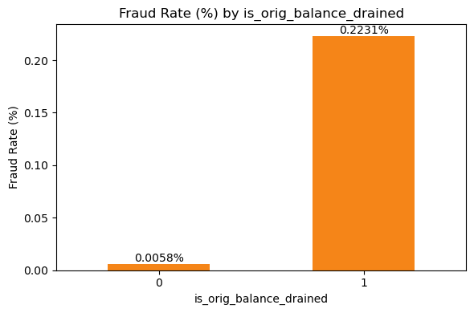

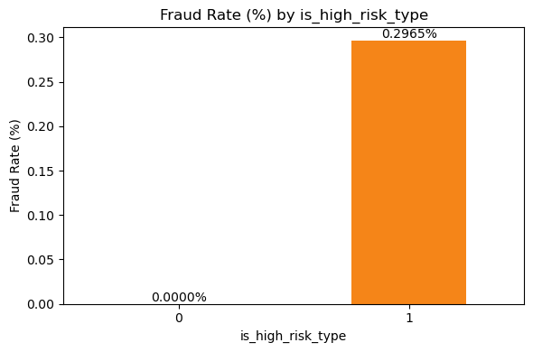

```python
for feature in binary_features:
    plot_data = binary_fraud_rate_tables[feature]["fraud_rate_percent"]
    ax = plot_data.plot(kind="bar", figsize=(6, 4), color="#F58518")
    plt.title(f"Fraud Rate (%) by {feature}")
    plt.xlabel(feature)
    plt.ylabel("Fraud Rate (%)")
    plt.xticks(rotation=0)

    for index, value in enumerate(plot_data):
        ax.text(index, value, f"{value:.4f}%", ha="center", va="bottom")

    plt.tight_layout()
    plt.show()
```

**Observation:** These binary fraud-rate tables show whether fraud is more common when a behavior is present. If the fraud rate is higher when `is_orig_balance_drained = 1`, account-draining behavior is a useful signal. If the fraud rate is higher when `is_high_risk_type = 1`, transaction type risk should be included in preprocessing.

### Continuous Feature Fraud Rates by Quantile Bin

For continuous features, we create ten quantile bins using `pd.qcut`. Quantile bins help compare fraud rates across low, medium, and high ranges of a feature while keeping the number of transactions in each bin more balanced.

```python
continuous_features = [
    "orig_balance_change",
    "orig_balance_error",
    "amount_to_oldbalanceOrg_ratio",
]

def calculate_quantile_fraud_rate(data, feature, q=10):
    temp = data[[feature, "isFraud"]].copy()
    bin_column = f"{feature}_bin"
    temp[bin_column] = pd.qcut(temp[feature], q=q, duplicates="drop")

    fraud_rate_table = temp.groupby(bin_column, observed=True).agg(
        total_count=("isFraud", "count"),
        fraud_count=("isFraud", "sum"),
        fraud_rate=("isFraud", "mean")
    )
    fraud_rate_table["fraud_rate_percent"] = fraud_rate_table["fraud_rate"] * 100
    return fraud_rate_table

continuous_fraud_rate_tables = {}

for feature in continuous_features:
    continuous_fraud_rate_tables[feature] = calculate_quantile_fraud_rate(eda_features, feature)

continuous_fraud_rate_tables["orig_balance_change"]
```

| orig_balance_change_bin | total_count | fraud_count | fraud_rate | fraud_rate_percent |
| --- | --- | --- | --- | --- |
| (-1915267.9009999998, -158095.782] | 636262 | 0 | 0.0000 | 0.0000 |
| (-158095.782, -26161.056] | 636262 | 0 | 0.0000 | 0.0000 |
| (-26161.056, 0.0] | 2215766 | 57 | 0.0000 | 0.0026 |
| (0.0, 908.0] | 329382 | 42 | 0.0001 | 0.0128 |
| (908.0, 6209.0] | 636181 | 130 | 0.0002 | 0.0204 |
| (6209.0, 14116.312] | 636243 | 168 | 0.0003 | 0.0264 |
| (14116.312, 34314.026] | 636262 | 410 | 0.0006 | 0.0644 |
| (34314.026, 10000000.0] | 636262 | 7406 | 0.0116 | 1.1640 |

**Observation for `orig_balance_change`:** This table shows whether fraud rate changes as origin account outflow increases. If higher bins have different fraud rates from lower bins, the feature may help models capture suspicious fund movement.

```python
continuous_fraud_rate_tables["orig_balance_error"]
```

| orig_balance_error_bin | total_count | fraud_count | fraud_rate | fraud_rate_percent |
| --- | --- | --- | --- | --- |
| (-92445516.641, -487768.968] | 636262 | 19 | 0.0000 | 0.0030 |
| (-487768.968, -304920.292] | 636262 | 6 | 0.0000 | 0.0009 |
| (-304920.292, -204553.16] | 636263 | 6 | 0.0000 | 0.0009 |
| (-204553.16, -131234.458] | 636261 | 3 | 0.0000 | 0.0005 |
| (-131234.458, -68677.255] | 636262 | 7 | 0.0000 | 0.0011 |
| (-68677.255, -23555.004] | 636262 | 3 | 0.0000 | 0.0005 |
| (-23555.004, -7538.534] | 636262 | 1 | 0.0000 | 0.0002 |
| (-7538.534, -2.91e-11] | 641551 | 14 | 0.0000 | 0.0022 |
| (-2.91e-11, 0.0] | 806594 | 8144 | 0.0101 | 1.0097 |
| (0.0, 0.01] | 460641 | 10 | 0.0000 | 0.0022 |

**Observation for `orig_balance_error`:** This table checks balance consistency. If fraud rate changes across error bins, this suggests that mismatches between transaction amount and origin balance movement may carry fraud information.

```python
continuous_fraud_rate_tables["amount_to_oldbalanceOrg_ratio"]
```

| amount_to_oldbalanceOrg_ratio_bin | total_count | fraud_count | fraud_rate | fraud_rate_percent |
| --- | --- | --- | --- | --- |
| (-0.001, 0.0293] | 636262 | 16 | 0.0000 | 0.0025 |
| (0.0293, 0.117] | 636262 | 1 | 0.0000 | 0.0002 |
| (0.117, 0.466] | 636262 | 47 | 0.0001 | 0.0074 |
| (0.466, 1.714] | 636262 | 8121 | 0.0128 | 1.2764 |
| (1.714, 6.454] | 636262 | 1 | 0.0000 | 0.0002 |
| (6.454, 36.294] | 636262 | 2 | 0.0000 | 0.0003 |
| (36.294, 4332.173] | 636262 | 0 | 0.0000 | 0.0000 |
| (4332.173, 30589.458] | 636262 | 1 | 0.0000 | 0.0002 |
| (30589.458, 175477.2] | 636262 | 8 | 0.0000 | 0.0013 |
| (175477.2, 92445516.64] | 636262 | 16 | 0.0000 | 0.0025 |

**Observation for `amount_to_oldbalanceOrg_ratio`:** This table shows whether fraud rate changes when the transaction amount becomes large relative to the origin account's starting balance. This is useful business logic because unusually large relative transfers may indicate suspicious behavior.

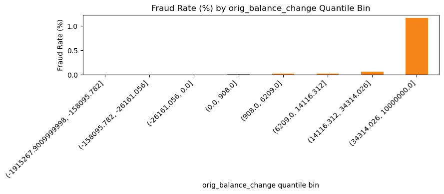

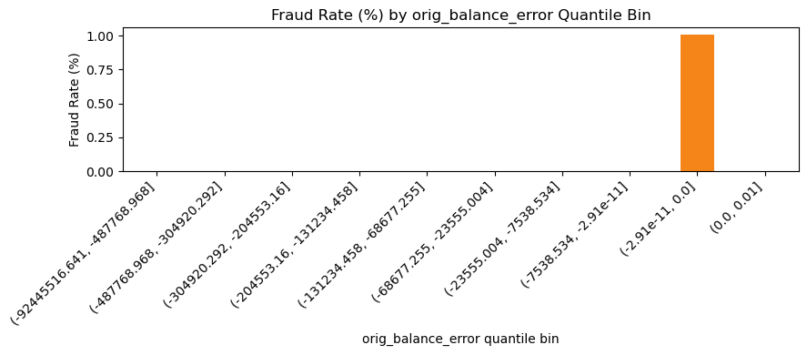

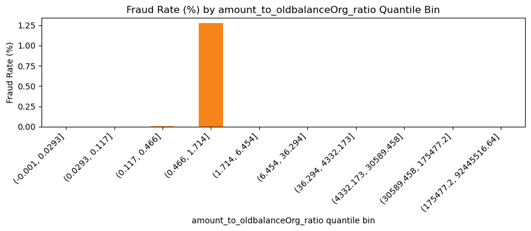

```python
for feature in continuous_features:
    plot_data = continuous_fraud_rate_tables[feature]["fraud_rate_percent"]
    ax = plot_data.plot(kind="bar", figsize=(9, 4), color="#F58518")
    plt.title(f"Fraud Rate (%) by {feature} Quantile Bin")
    plt.xlabel(f"{feature} quantile bin")
    plt.ylabel("Fraud Rate (%)")
    plt.xticks(rotation=45, ha="right")
    plt.tight_layout()
    plt.show()
```

**Observation:** Fraud-rate analysis is useful in EDA because it connects raw transaction behavior with the target variable in a simple, interpretable way. If fraud rate changes across feature groups or bins, the feature is a stronger candidate for ML preprocessing. Based on this analysis, `orig_balance_change`, `orig_balance_error`, `amount_to_oldbalanceOrg_ratio`, `is_orig_balance_drained`, and `is_high_risk_type` should be considered for `preprocessing.py`.

**Target leakage warning:** These fraud-rate tables should not be directly used as training features. They are calculated using the target column `isFraud`, so turning the table values into model inputs would leak label information into training. The safe approach is to create the engineered features from transaction fields only, then let models learn patterns from the training data.

## 16. Final Summary

### Dataset Overview

- PaySim contains millions of financial transactions for simulated mobile money activity.
- The target variable is `isFraud`, and it is highly imbalanced because fraud transactions are rare.

### Fraud Pattern Findings

- Fraud cases are concentrated in `TRANSFER` and `CASH_OUT` transaction types.
- Fraud transactions show different amount and balance-change patterns from normal transactions.
- Log-scale and percentage-based charts are useful because normal transactions heavily outnumber fraud transactions.

### Feature Engineering Justification

- The EDA supports creating behavior-based features from raw transaction fields.
- `orig_balance_change` captures fund outflow from the origin account.
- `orig_balance_error` captures origin-side balance consistency.
- `amount_to_oldbalanceOrg_ratio` captures transaction size relative to origin balance.
- `is_orig_balance_drained` captures account-draining behavior.
- `is_high_risk_type` captures transaction-type risk for `TRANSFER` and `CASH_OUT`.
- Destination-side features such as `dest_balance_change` and `dest_balance_error` may also be kept as supplementary fund-flow features in `preprocessing.py`, even though the main EDA justification focuses on the five representative features.

### Evaluation Implication

- Because fraud is rare, accuracy alone is not enough.
- Later models should be evaluated using Recall, Precision, F1-score, ROC-AUC, PR-AUC, and a confusion matrix.

### Next Step

- Build `preprocessing.py` to create these engineered features consistently.
- Use `02_financial_ml_baseline.ipynb` to compare Logistic Regression, Random Forest, and XGBoost.
- Select one primary supervised fraud detection model for the V1 risk scoring system.